# 15b_alternative_cluster_tests.Rmd

Joanna Schroeder

9/11/2020

How does time to run Ward's vs PAM vs DIANA clustering differ with scale?

We will test this using sequence objects with 1,000, 2,000, and 4,000 members for Ward's and PAM. For DIANA, we will test a 4,000 member sample for all possible properties.

## Definitions

- Ward's
- Agglomerative hierarchical clustering, minimizes median distances between groups.
- PAM (Partitioning around medoids)
- Direct partitioning, minimizes dissimilarities within the cluster. Faster, number of clusters set before.
- DIANA (divisive analysis)
- Divisive analysis is the opposite of agglomerative. It is hierarchical clustering, better at identifying large than small clusters

## Create sequence objects

```r
set.seed(09112020)

sts_nonvet <- read.csv("~/git/DSPG2020/career/data/sts_all_ten.csv", row.names = 1)

small <- sts_nonvet[sample(nrow(sts_nonvet), 1000, replace = FALSE, prob = NULL),]
medium <- sts_nonvet[sample(nrow(sts_nonvet), 2000, replace = FALSE, prob = NULL),]
large <- sts_nonvet[sample(nrow(sts_nonvet), 4000, replace = FALSE, prob = NULL),]

small <- seqdef(small, left="DEL", gaps="Civilian unemployment", right="DEL", cpal = c("#CBBEB5",  uva_color_palette[1], uva_color_palette[2],uva_color_palette[4],  uva_color_palette[6], uva_color_palette[9], "#CBBEB5"))

medium <- seqdef(medium, left="DEL", gaps="Civilian unemployment", right="DEL", cpal = c("#CBBEB5",  uva_color_palette[1], uva_color_palette[2],uva_color_palette[4],  uva_color_palette[6], uva_color_palette[9], "#CBBEB5"))

large <- seqdef(large, left="DEL", gaps="Civilian unemployment", right="DEL", cpal = c("#CBBEB5",  uva_color_palette[1], uva_color_palette[2],uva_color_palette[4],  uva_color_palette[6], uva_color_palette[9], "#CBBEB5"))
```

Our sample data comes from a sample of nonveterans who have at least ten years of employment history. We will cluster based on the whole sequence and in exploratory plots limit the axis to the first 30 years of employment history.

## 1,000 member clustering

```r
reps = 1:10
diss <- seqdist(small, method = "OM", indel = 1, sm = "TRATE", with.missing = TRUE, norm = TRUE)

cluster_times <- for(rep in reps) {
rep = as.character(rep)

# Ward's clustering
start_w <- Sys.time()
clusterward <- agnes(diss, diss = TRUE, method = "ward")
end_w <- Sys.time()
assign(paste0("w_run_", rep), (end_w - start_w), envir = .GlobalEnv)

# PAM clustering
start_p <- Sys.time()
clusterpam <- wcKMedoids(diss, k = 8)
end_p <- Sys.time()
assign(paste0("p_run_", rep), (end_p - start_p), envir = .GlobalEnv)

assign("clusterward_s", clusterward, envir = .GlobalEnv)
assign("clusterpam_s", clusterpam, envir = .GlobalEnv)
}

small_w_time <- mean.difftime((w_run_1 + w_run_2 + w_run_3 + w_run_4 + w_run_5 + w_run_6 + w_run_7 + w_run_8 + w_run_9 + w_run_10)/10)

small_p_time <- mean.difftime((p_run_1 + p_run_2 + p_run_3 + p_run_4 + p_run_5 + p_run_6 + p_run_7 + p_run_8 + p_run_9 + p_run_10)/10)

small_w_time
```

```
## Time difference of 0.7235906 secs
```

```r
small_p_time
```

```
## Time difference of 0.3607806 secs
```

In small samples PAM is about twice as fast.

## 2,000 member clustering

```r
# Normal clustering

reps = 1:5
diss <- seqdist(medium, method = "OM", indel = 1, sm = "TRATE", with.missing = TRUE, norm = TRUE)

cluster_times <- for(rep in reps) {
rep = as.character(rep)

# Ward's cluster
start_w <- Sys.time()
clusterward <- agnes(diss, diss = TRUE, method = "ward")
end_w <- Sys.time()
assign(paste0("w_run_", rep), (end_w - start_w), envir = .GlobalEnv)

# PAM cluster
start_p <- Sys.time()
clusterpam <- wcKMedoids(diss, k = 8)
end_p <- Sys.time()
assign(paste0("p_run_", rep), (end_p - start_p), envir = .GlobalEnv)

assign("clusterward_m", clusterward, envir = .GlobalEnv)
assign("clusterpam_m", clusterpam, envir = .GlobalEnv)
}

medium_w_time <- mean.difftime((w_run_1 + w_run_2 + w_run_3 + w_run_4 + w_run_5)/5)

medium_p_time <- mean.difftime((p_run_1 + p_run_2 + p_run_3 + p_run_4 + p_run_5)/5)

medium_w_time
```

```
## Time difference of 6.056397 secs
```

```r
medium_p_time
```

```
## Time difference of 2.189459 secs
```

## 4,000 member clustering

```r
# Normal clustering

reps = 3
diss <- seqdist(large, method = "OM", indel = 1, sm = "TRATE", with.missing = TRUE, norm = TRUE)

cluster_times <- for (rep in reps) {
rep = as.character(rep)

start_w <- Sys.time()
clusterward <- agnes(diss, diss = TRUE, method = "ward")
end_w <- Sys.time()
assign(paste0("w_run_", rep), (end_w - start_w), envir = .GlobalEnv)

# Weighted clustering
start_p <- Sys.time()
clusterpam <- wcKMedoids(diss, k = 8)
end_p <- Sys.time()
assign(paste0("p_run_", rep), (end_p - start_p), envir = .GlobalEnv)

assign("clusterward_l", clusterward, envir = .GlobalEnv)
assign("clusterpam_l", clusterpam, envir = .GlobalEnv)
}

large_w_time <- mean.difftime((w_run_1 + w_run_2 + w_run_3)/3)

large_p_time <- mean.difftime((p_run_1 + w_run_2 + p_run_3)/3)

large_w_time
```

```
## Time difference of 34.50542 secs
```

```r
large_p_time
```

```
## Time difference of 6.03019 secs
```

In large samples PAM is more than twice as fast.

## Time table

```r
times <- tibble("type" = c("unweighted", "weighted"),
                "1000" = c(small_w_time, small_p_time),
                "2000" = c(medium_w_time, medium_p_time),
                "4000" = c(large_w_time, large_p_time))

times
```

```
## # A tibble: 2 x 4
##   type       `1000`         `2000`        `4000`
##   <chr>      <drtn>         <drtn>        <drtn>
## 1 unweighted 0.7235906 secs 6.056397 secs 34.50542 secs
## 2 weighted   0.3607806 secs 2.189459 secs  6.03019 secs
```

Overall PAM is faster than Ward's at all levels, with the difference increasing as the sample size increases. Though even the "large" sample runs for both methods in under a minute, it is important to remember we are interested in clustering sequence objects with 40,000+ members.

(Assuming no differences in the cluster outputs) Because of the flexible nature of Ward's clustering (number of clusters selected after clustering), it may be advantageous to perform exploratory analysis to decide number of clusters on a small sample using Ward's method before clustering the whole object with PAM.

# Cluster differences

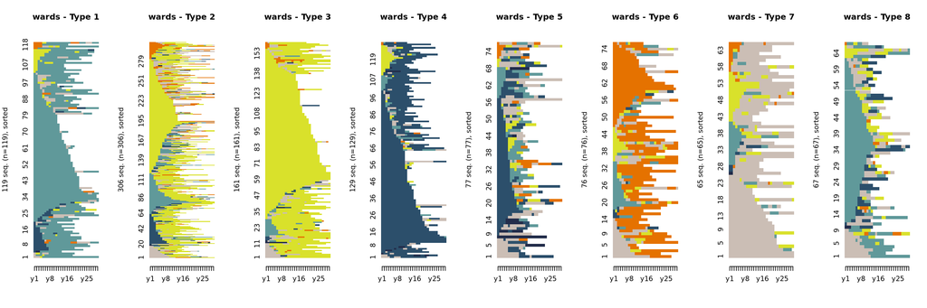

```r
# small clusters
clusterward_8 <- cutree(clusterward_s, k = 8)
clusterward_8_fac <- factor(clusterward_8, labels = paste("Type", 1:8))

clusterpam_8 <- clusterpam_s$clustering
clusterpam_8_fac <- factor(clusterpam_8, labels = paste("Type", 1:8))

clusterpam_8_fac <- factor(clusterpam_8_fac, levels = c("Type 2", "Type 8", "Type 3", "Type 7", "Type 4", "Type 5", "Type 1", "Type 6"))

par(mfrow=c(1,3))
w_plot <- seqIplot(small[,1:30], group = clusterward_8_fac, border = NA, use.layout = TRUE, cols = 8, withlegend = F, sortv = "from.start", main = "wards")
```

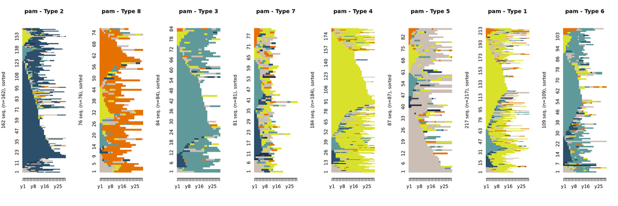

```r
p_plot <- seqIplot(small[,1:30], group = clusterpam_8_fac, border = NA, use.layout = TRUE, cols = 8, withlegend = F, sortv = "from.start", main = "pam")
```

```r
seqlegend(small)

as.data.frame(clusterward_8_fac) %>%
  group_by(clusterward_8_fac) %>% summarise(n = n())
```

```
## # A tibble: 8 x 2
##   clusterward_8_fac     n
##   <fct>             <int>
## 1 Type 1              119
## 2 Type 2              306
## 3 Type 3              161
## 4 Type 4              129
## 5 Type 5               77
## 6 Type 6               76
## 7 Type 7               65
## 8 Type 8               67
```

```r
as.data.frame(clusterpam_8_fac) %>%
  group_by(clusterpam_8_fac) %>% summarise(n = n())
```

```
## # A tibble: 8 x 2
##   clusterpam_8_fac     n
##   <fct>            <int>
## 1 Type 2             162
## 2 Type 8              76
## 3 Type 3              84
## 4 Type 7              81
## 5 Type 4             184
## 6 Type 5              87
## 7 Type 1             217
## 8 Type 6             109
```

```r
# medium clusters
clusterward_8 <- cutree(clusterward_m, k = 8)
clusterward_8_fac <- factor(clusterward_8, labels = paste("Type", 1:8))

clusterpam_8 <- clusterpam_m$clustering
clusterpam_8_fac <- factor(clusterpam_8, labels = paste("Type", 1:8))

clusterpam_8_fac <- factor(clusterpam_8_fac, levels = c("Type 2", "Type 8", "Type 3", "Type 7", "Type 4", "Type 5", "Type 1", "Type 6"))

par(mfrow=c(1,3))
```

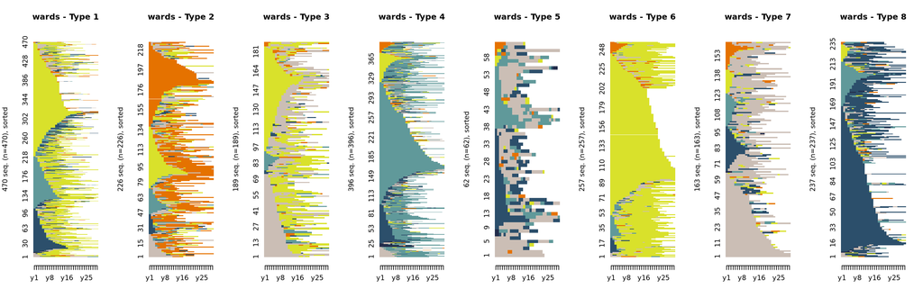

```r
w_plot <- seqIplot(medium[,1:30], group = clusterward_8_fac, border = NA, use.layout = TRUE, cols = 8, withlegend = F, sortv = "from.start", main = "wards")
```

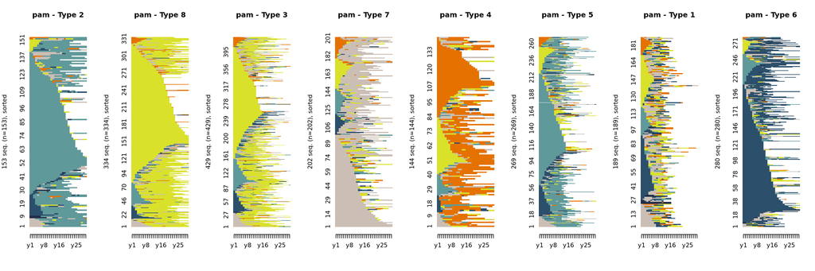

```r
p_plot <- seqIplot(medium[,1:30], group = clusterpam_8_fac, border = NA, use.layout = TRUE, cols = 8, withlegend = F, sortv = "from.start", main = "pam")
```

```r
seqlegend(medium)

as.data.frame(clusterward_8_fac) %>%
  group_by(clusterward_8_fac) %>% summarise(n = n())
```

```
## # A tibble: 8 x 2
##   clusterward_8_fac     n
##   <fct>             <int>
## 1 Type 1              470
## 2 Type 2              226
## 3 Type 3              189
## 4 Type 4              396
## 5 Type 5               62
## 6 Type 6              257
## 7 Type 7              163
## 8 Type 8              237
```

```r
as.data.frame(clusterpam_8_fac) %>%
  group_by(clusterpam_8_fac) %>% summarise(n = n())
```

```
## # A tibble: 8 x 2
##   clusterpam_8_fac     n
##   <fct>            <int>
## 1 Type 2             153
## 2 Type 8             334
## 3 Type 3             429
## 4 Type 7             202
## 5 Type 4             144
## 6 Type 5             269
## 7 Type 1             189
## 8 Type 6             280
```

```r
# large clusters
clusterward_8 <- cutree(clusterward, k = 8)
clusterward_8_fac <- factor(clusterward_8, labels = paste("Type", 1:8))

clusterpam_8 <- clusterpam$clustering
clusterpam_8_fac <- factor(clusterpam_8, labels = paste("Type", 1:8))

clusterpam_8_fac <- factor(clusterpam_8_fac, levels = c("Type 2", "Type 8", "Type 3", "Type 7", "Type 4", "Type 5", "Type 1", "Type 6"))

par(mfrow=c(1,3))
```

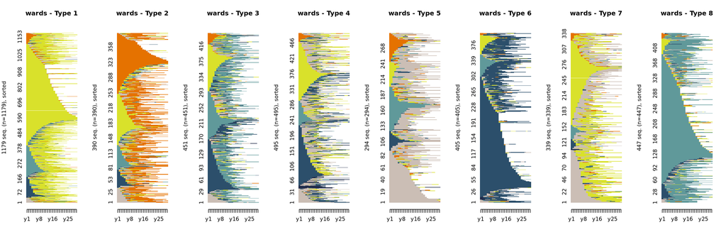

```r
w_plot <- seqIplot(large[,1:30], group = clusterward_8_fac, border = NA, use.layout = TRUE, cols = 8, withlegend = F, sortv = "from.start", main = "wards")
```

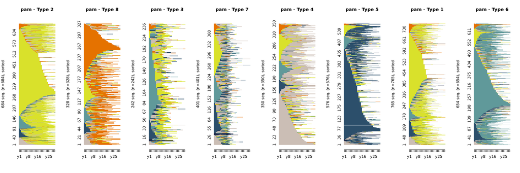

```r
p_plot <- seqIplot(large[,1:30], group = clusterpam_8_fac, border = NA, use.layout = TRUE, cols = 8, withlegend = F, sortv = "from.start", main = "pam")
```

```r
seqlegend(large)

as.data.frame(clusterward_8_fac) %>%
  group_by(clusterward_8_fac) %>% summarise(n = n())
```

```
## # A tibble: 8 x 2
##   clusterward_8_fac     n
##   <fct>             <int>
## 1 Type 1             1179
## 2 Type 2              390
## 3 Type 3              451
## 4 Type 4              495
## 5 Type 5              294
## 6 Type 6              405
## 7 Type 7              339
## 8 Type 8              447
```

```r
as.data.frame(clusterpam_8_fac) %>%
  group_by(clusterpam_8_fac) %>% summarise(n = n())
```

```
## # A tibble: 8 x 2
##   clusterpam_8_fac     n
##   <fct>            <int>
## 1 Type 2             684
## 2 Type 8             328
## 3 Type 3             242
## 4 Type 7             401
## 5 Type 4             350
## 6 Type 5             576
## 7 Type 1             765
## 8 Type 6             654
```

Overall the clusters look pretty similar. The biggest differences are the Ward's solution has two unemployment clusters. The PAM solution has a career mobility cluster (Type 3). Surprisingly, the PAM cluster solution has a more even distribution (523 range) than the Ward's (885 range) solution.

The similar cluster outputs support choosing Ward's or PAM clustering based on desired efficiency in flexibility in the number of clusters or a quicker runtime varying with sample size. It is likely that choosing a specific dissimilarity metric or performing DIANA clustering will have a greater impact on the cluster outputs.

## DIANA clustering

The creators of the TraMineR and WeightedCluster package have created tools to implement monothetic divise clustering of sequences in R (https://link.springer.com/chapter/10.1007/978-3-319-95420-2_13). This type of clustering is reffered to as property based clustering, as it gives us more control over the specific properties of sequences used to create clusters.

- state: The state in which an individual is found, at each time position t
- spell.age: The age at the beginning of each spell of a given type
- spell.dur: The duration of each of the spells presented above
- duration: The total time spent in each state
- pattern: Count of the frequent subsequences of states in the distinct successive states
- AFpattern: Age at the first occurrence of the above frequent subsequence
- transition: Count of the frequent subsequence of events in each sequence, where each transition is considered another event
- AFtransition: Age at the first occurrence of the above frequent subsequence
- Complexity: Complexity index, number of transitions, turbulence

Here we test the speed of clustering by each of these properties with the large subset.

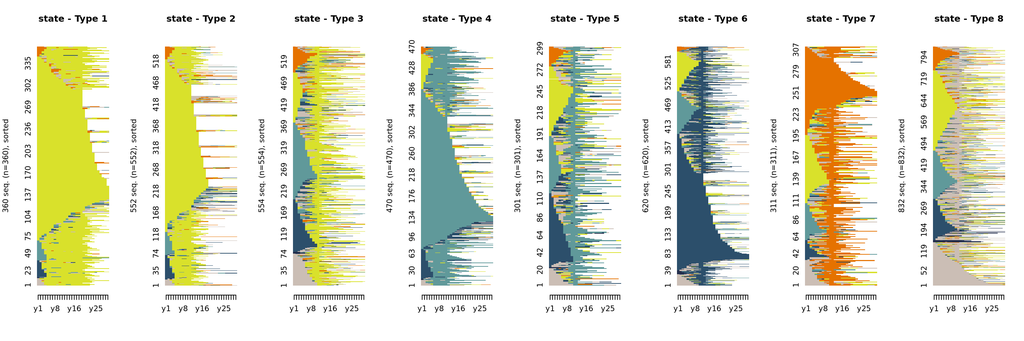

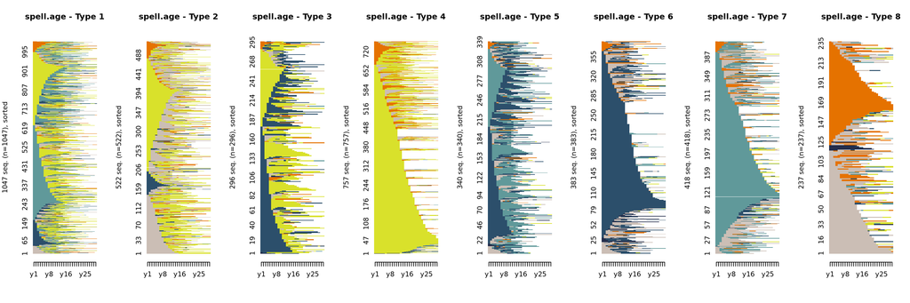

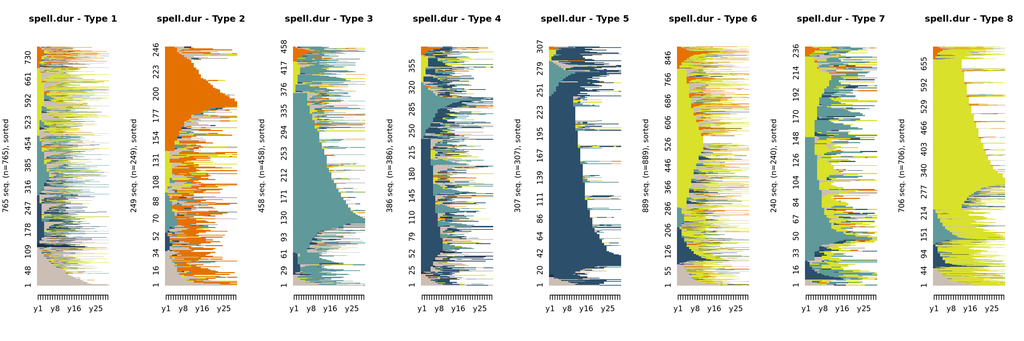

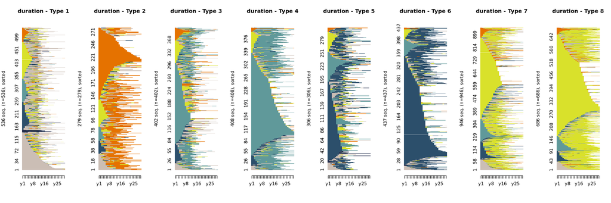

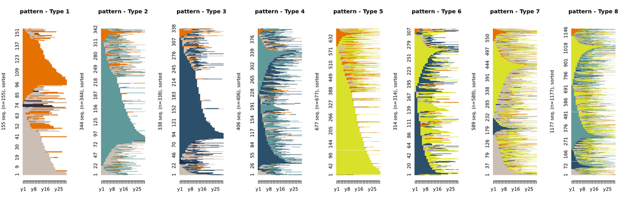

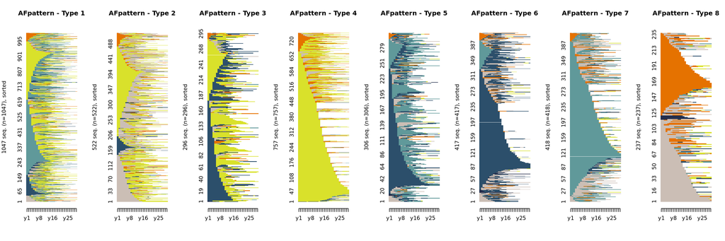

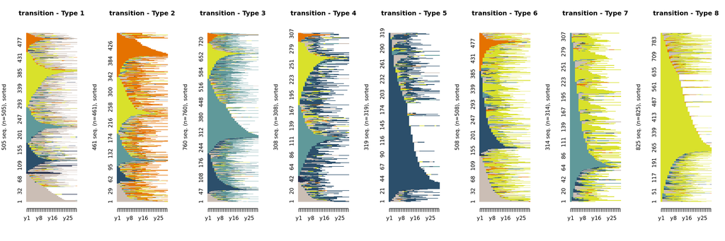

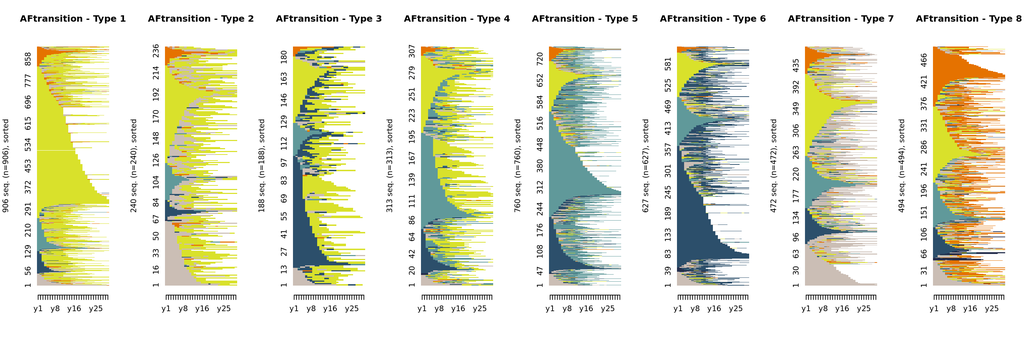

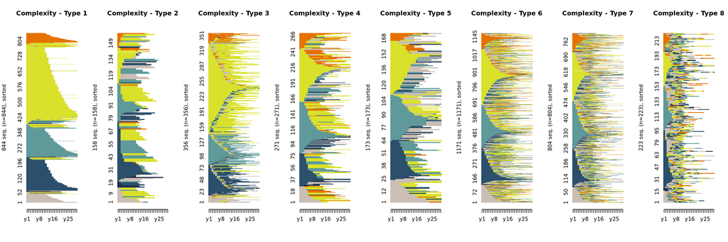

```r
properties <- c("state", "spell.age", "spell.dur", "duration", "pattern", "AFpattern", "transition", "AFtransition", "Complexity")

for (property in properties) {
start_prop <- Sys.time()
clusterprop <- seqpropclust(large, diss = diss, properties = property, maxcluster = 8)
end_prop <- Sys.time()

clusterprop_8 <- clusterprop$fitted
clusterprop_10_fac <- factor(clusterprop_8$`(fitted)`, labels = paste("Type", 1:8))

prop_plot <- seqIplot(large[,1:30], group = clusterprop_10_fac, border = NA, use.layout = TRUE, cols = 8, withlegend = F, sortv = "from.start", main = property)

assign(paste0("prop_run_", property), (end_prop - start_prop), envir = .GlobalEnv)
assign(property, prop_plot, envir = .GlobalEnv)
}
```

```r
prop_run_state
```

```
## Time difference of 5.199502 secs
```

```r
prop_run_spell.age
```

```
## Time difference of 3.072638 secs
```

```r
prop_run_spell.dur
```

```
## Time difference of 3.299173 secs
```

```r
prop_run_duration
```

```
## Time difference of 1.161098 secs
```

```r
prop_run_pattern
```

```
## Time difference of 6.238233 secs
```

```r
prop_run_AFpattern
```

```
## Time difference of 8.739172 secs
```

```r
prop_run_transition
```

```
## Time difference of 4.371749 secs
```

```r
prop_run_AFtransition
```

```
## Time difference of 4.357616 secs
```

```r
prop_run_Complexity
```

```
## Time difference of 3.899962 mins
```

```r
prop_time <- mean.difftime((prop_run_state + prop_run_spell.age + prop_run_spell.dur + prop_run_duration + prop_run_pattern + prop_run_AFpattern + prop_run_transition + prop_run_AFtransition + prop_run_Complexity)/9)

prop_time
```

```
## Time difference of 30.04855 secs
```

state: The state in which an individual is found, at each time position t Clustered by state in early, mid, and late career. Clusters 1 and 2 are Zone 4 early career, Cluster 3 is Zone 4 mid career. Cluster 4 is Zone 3 early career. Cluster 5 is Zone 3 mid career. Cluster 6 is Zone 2 mid career. Cluster 7 is zone 5 mid career. Cluster 8 is missing/unemployed mid career. Pretty similar to PAM and Wards Solutions

spell.age: The age at the beginning of each spell of a given type I think these are emphasizing the relationships between subsequence or two states. Type 1 is Zone 4 and Zone 3, Type 2 is Zone 4 and Unemployment/Missing, Type 3 is Zone 4 and Zone 2, Type 4 is Zone 4 and Zone 5, Type 5 is Zone 3 and Zone 2, Type 8 is Zone 5 and unemployment/missing.

spell.dur: The duration of each of the spells presented above duration: The total time spent in each state These look pretty similar, though you can see how duration slightly preferences single state durations whereas spell.dur preferences subsequence durations

pattern: Count of the frequent subsequences of states in the distinct successive states AFpattern: Age at the first occurrence of the above frequent subsequence Pretty similar

transition: Count of the frequent subsequence of events in each sequence, where each transition is considered another event AFtransition: Age at the first occurrence of the above frequent subsequence These look pretty similar but the most different of AF pairs.

Complexity: Complexity index, number of transitions, turbulence These are interesting though maybe not as useful as others. I think Type 3 is really interesting, with a mid-career zone change, back to the original zone. I wonder if this may be more useful with less clusters.